# seminario202

Felipe Palomino

2023-08-24

## **Medidas de posición, centro, dispersión y forma**

Al contar con una variable en general es necesario obtener medidas que nos puedan resumir de una sintetizada la información obtenida en ella. Una alternativa que nos brinda la estadística descriptiva son las medidas de posición, centro, dispersión y forma.

Antes de empezar a definir cada concepto pensemos inicialmente en una variable para identificar cada una de ellas.Supongamos que un laboratorio químico está analizando la concentración de un compuesto en muestras de agua tomadas de diferentes fuentes naturales. Se han recopilado los siguientes datos de concentraciones (en mg/L) para 15 muestras de agua:

35, 42, 50, 55, 58, 62, 65, 70, 75, 80, 85, 90, 95, 98, 100

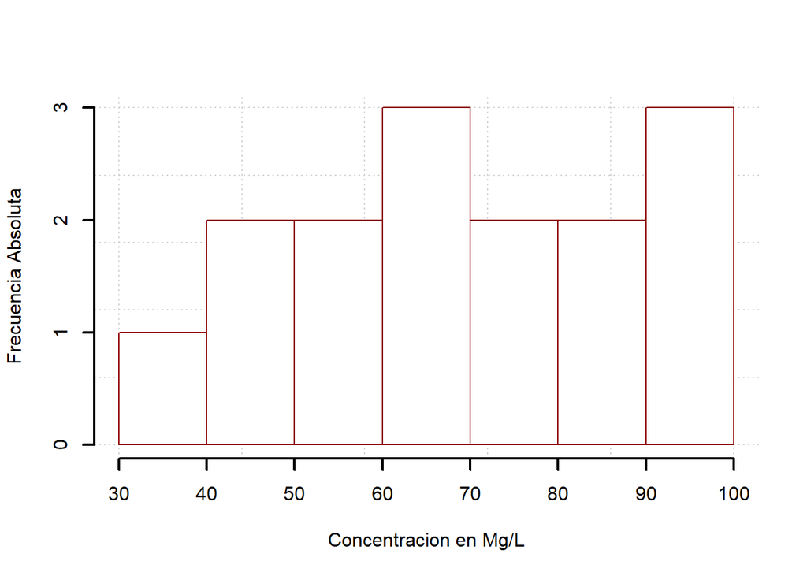

```r
#Inializaremos estos datos en R, para trabajar con ellos:
Cocentracion<-c(35, 42, 50, 55, 58, 62, 65, 70, 75, 80, 85, 90, 95, 98, 100)
#Gráfiquemos un histograma de estos mismos
hist(Cocentracion,xlab="Concentracion en Mg/L",ylab="Frecuencia Absoluta",panel.first=grid(),col="white",border="red4",lwd=2,main="")
```

```r
#En el camino de este capítulo realizaremos su análisis
```

**Medidas de posición** Las medidas de posición hacen enfásis a una estrcutura de los datos ordenada e identificar cual es el valor que nos describe que hasta ese punto se encuentra el “x”% de valores.Es decir hasta una concentración de 50 Mg/L que porcentaje de valores se encuentran ubicados.También se pueden entender como subdivisiones de los datos, es decir cuales son esos valores que me generan una división en 2,4,100 grupos.

Las medidas de posición más utilizadas son:

**Mediana**:

La mediana es el valor que divide un conjunto de datos en dos partes iguales, de manera que el 50% de los datos están por encima de la mediana y el 50% están por debajo. Para calcularla, primero se ordenan los datos y se encuentra el valor central si el número de datos es impar, o el promedio de los dos valores centrales si el número de datos es par.

**Percentiles**:

Los percentiles dividen un conjunto de datos en cien partes iguales. El percentil P representa el valor por debajo del cual se encuentra P% de los datos. Por ejemplo, el percentil 25 (P25) es el valor por debajo del cual se encuentra el 25% de los datos.

**Cuartiles**:

Los cuartiles son percentiles específicos que dividen un conjunto de datos en cuatro partes iguales. Los cuartiles más utilizados son el primer cuartil (Q1, equivalente al percentil 25), el segundo cuartil (Q2, equivalente a la mediana o percentil 50) y el tercer cuartil (Q3, equivalente al percentil 75). **Rango intercuartil (RIC)**:

El rango intercuartil es la diferencia entre el tercer cuartil (Q3) y el primer cuartil (Q1). Es una medida de dispersión que indica cuánto se extienden los valores en el rango central del conjunto de datos.

```r
#Podemos obtener todas estas medidas de una manera sencilla através de las siguientes funciones
quantile(Cocentracion,c(0.10,0.25,0.5,0.75,0.9)) #Debemos reemplazar como argumento inicial nuestro vector con valores, seguido de los percentiles de interés. En este caso obtenemos el percentil 10, o primer decil, primer cuartil, mediana, tercer cuartil y percentil 90% respectivamente
```

```
##  10%  25%  50%  75%  90%
## 45.2 56.5 70.0 87.5 96.8
```

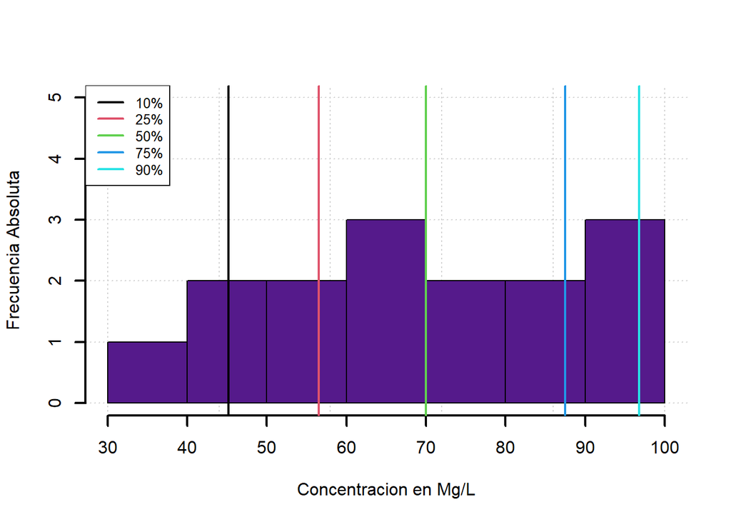

```r
#Gráfiquemoslo en el histograma
hist(Cocentracion,xlab="Concentracion en Mg/L",ylab="Frecuencia Absoluta",panel.first=grid(),col="purple4",lwd=2,main="",ylim=c(0,5))
Percentiles<-quantile(Cocentracion,c(0.10,0.25,0.5,0.75,0.9))
abline(v=Percentiles,lwd=2,col=c(1,2,3,4,5))
legend("topleft",legend=c("10%","25%","50%","75%","90%"),col=c(1,2,3,4,5),
       lwd=2,cex=0.8)
```

**Medidas de tendencia central** Las medidas de tendencia central, también conocidas como medidas de centralización, son estadísticas utilizadas para resumir y representar la ubicación central o típica de un conjunto de datos. Estas medidas proporcionan información sobre dónde se agrupan o concentran los valores en un conjunto de datos. Las medidas de tendencia central más comunes son:

**Media Aritmética**: La media aritmética es el promedio de todos los valores en un conjunto de datos. Se calcula sumando todos los valores y dividiendo la suma por el número total de valores. La media se denota como:

$$\bar{x}=\frac{\sum_{i}^{n}x_{i}}{n}$$

**Mediana**: La mediana es el valor que se encuentra en el punto medio de un conjunto de datos cuando los valores están ordenados de menor a mayor (o viceversa). Si hay un número impar de valores, la mediana es el valor central. Si hay un número par de valores, la mediana es el promedio de los dos valores centrales.

**Moda**: La moda es el valor que aparece con mayor frecuencia en un conjunto de datos. Puede haber una moda (un valor que se repite con más frecuencia) o múltiples modas si varios valores tienen la misma frecuencia máxima.

```r
#Podemos obtener estos indicadores de la siguiente manera
mode <- function(x) {
   return(as.numeric(names(which.max(table(x)))))
} #Creando una función para la moda
print("Media")
```

```
## [1] "Media"
```

```r
mean(Cocentracion)
```

```
## [1] 70.66667
```

```r
print("Mediana")
```

```
## [1] "Mediana"
```

```r
median(Cocentracion)
```

```
## [1] 70
```

```r
print("Moda")
```

```
## [1] "Moda"
```

```r
mode(Cocentracion)
```

```
## [1] 35
```

**Medidas de dispersión** Las medidas de dispersión son estadísticas que proporcionan información sobre la variabilidad o dispersión de un conjunto de datos. Ayudan a entender cuánto se extienden los valores alrededor de una medida central (como la media) en el conjunto de datos. Las principales medidas de dispersión incluyen:

**Rango**: El rango es la diferencia entre el valor máximo y el valor mínimo en un conjunto de datos. Es la medida de dispersión más simple y fácil de calcular.

**Desviación Estándar (SD)**: La desviación estándar mide la dispersión de los valores con respecto a la media. Una desviación estándar más grande indica una mayor dispersión. Se calcula como la raíz cuadrada de la varianza.

**Varianza**: La varianza es una medida de la dispersión que calcula la media de los cuadrados de las diferencias entre cada valor y la media. Una varianza más grande indica una mayor dispersión. La varianza poblacional se denota como $\sigma^2$, y la muestral se denota como $s^2$, tiene como expresión:

$$\sigma^2=\frac{\sum_{i}^{n}({x_{i}-\bar{x}})}{n}$$
$$S^2=\frac{\sum_{i}^{n}({x_{i}-\bar{x}})}{n-1}$$
Rango Intercuartil (RIC): El rango intercuartil es la diferencia entre el tercer cuartil (Q3) y el primer cuartil (Q1). Se utiliza para medir la dispersión en la parte central de un conjunto de datos, ignorando los valores extremos.

Coeficiente de Variación (CV): El coeficiente de variación es una medida relativa de la dispersión que compara la desviación estándar con la media. Se expresa como un porcentaje y se utiliza para comparar la dispersión en diferentes conjuntos de datos. Su expresión es:
$$CV=\frac{SD}{|\bar{x}|}*100$$

```r
#Podemos  estas medidas de la siguiente manera
print("Varianza")
```

```
## [1] "Varianza"
```

```r
var(Cocentracion)
```

```
## [1] 422.8095
```

```r
print("Desviación Estandar")
```

```
## [1] "Desviación Estandar"
```

```r
sd(Cocentracion)
```

```
## [1] 20.56233
```

```r
print("Coef Var")
```

```
## [1] "Coef Var"
```

```r
sd(Cocentracion)/abs(mean(Cocentracion))
```

```
## [1] 0.2909764
```

```r
print("Rango")
```

```
## [1] "Rango"
```

```r
range(Cocentracion)
```

```
## [1]  35 100
```

**Medidas de forma** Las medidas de forma, a veces llamadas medidas de asimetría y curtosis, se utilizan para describir la forma o la distribución de un conjunto de datos. A continuación, se presentan algunas de las medidas de forma más comunes:

**Asimetría (Skewness)**: La asimetría mide la falta de simetría en la distribución de los datos. Indica si los datos están sesgados hacia la izquierda (negativo), hacia la derecha (positivo) o si tienen una distribución simétrica (cero). Un valor de asimetría igual a cero indica simetría perfecta.

**Asimetría positiva (derecha)**: La cola de la distribución se extiende más hacia la derecha y la mayoría de los datos se concentran en valores más bajos que la media.

**Asimetría negativa (izquierda)**: La cola de la distribución se extiende más hacia la izquierda y la mayoría de los datos se concentran en valores más altos que la media.

**Curtosis (Kurtosis)**: La curtosis mide la concentración de los datos alrededor de la media y la forma de las colas de la distribución. Indica si los datos tienen colas pesadas (mayor concentración en los valores extremos) o colas ligeras (menos concentración en los valores extremos).

**Curtosis positiva (leptocúrtica)**: Indica una mayor concentración de datos alrededor de la media con colas pesadas. Esto puede indicar una distribución más puntiaguda en el centro.

**Curtosis negativa (platicúrtica)**: Indica una menor concentración de datos alrededor de la media con colas ligeras. Esto puede indicar una distribución más aplanada en el centro.

**Curtosis igual a cero (mesocúrtica)**: Indica una distribución normal con colas moderadas.

Estas medidas de forma proporcionan información adicional sobre la distribución de los datos más allá de las medidas de tendencia central y dispersión. Ayudan a caracterizar la simetría, la concentración y la forma de la distribución, lo que puede ser importante en análisis estadísticos más avanzados y en la comprensión de la naturaleza de los datos.

```r
#Medidas de forma en R
library(moments)
print("Asimetría")
```

```
## [1] "Asimetría"
```

```r
skewness(Cocentracion)
```

```
## [1] -0.1133882
```

```r
print("Curtosis")
```

```
## [1] "Curtosis"
```

```r
kurtosis(Cocentracion)
```

```
## [1] 1.886922
```